# Tarea 11

Curso de Estadística Descriptiva

9/1/2019

## Responded a las preguntas de forma razonada y argumentada.

### Preguntas de esta tarea

#### Dad la instrucción que defina la tabla de frecuencias absolutas de un vector llamado “alumnos”

```r
alumnos = c("Joaquín", "Ana", "Merchi", "Mario", "Marypaz", "Marypaz", "Ruben", "Ana", "Pedro", "Joaquín", "JoaquínMarypaz", "Ana", "Joaquín", "Joaquín", "María", "Ana", "Mario", "Ruben", "Juan", "Ruben", "JoaquínMario", "Ruben", "Javi", "Ignacio", "Hugo", "María", "Juan", "Ignacio", "Marypaz", "Ana", "Hugo", "Paqui", "Ignacio", "Ruben", "Mario", "Paula", "Marypaz", "Joaquín", "Javi", "Paula", "Paqui", "Paula", "Paula", "Joaquín", "Hugo", "Pedro", "Merchi", "Juan", "Marypaz", "María", "Ignacio", "Ignacio", "Hugo", "Ana", "Marypaz", "Ignacio", "Javi", "Hugo", "Mario", "Ignacio", "Marypaz", "Marypaz", "Merchi", "Paqui", "Ruben", "Javi", "María", "Paqui", "Hugo", "Marypaz", "Ruben", "Pedro", "Paqui", "Joaquín", "Paqui", "Marypaz", "Ruben", "Ana", "Ana", "Javi", "Hugo", "Ruben", "Juan", "Juan", "Ana", "Pedro", "Paula", "Hugo", "Paqui", "Joaquín", "Merchi", "María", "Mario", "Javi", "Javi", "Javi", "Merchi", "Juan")

table(alumnos)
```

```
## alumnos
##            Ana           Hugo        Ignacio           Javi        Joaquín
##              9              8              7              8              8
##   JoaquínMario JoaquínMarypaz           Juan          María          Mario
##              1              1              6              5              5
##        Marypaz         Merchi          Paqui          Paula          Pedro
##             10              5              7              5              4
##          Ruben
##              9
```

#### Con una sola instrucción, definid la tabla de frecuencias relativas de un vector llamado “edades”

```r
edades = c(22, 20, 25, 22, 22, 22, 22, 25, 22, 22, 22, 20, 22, 25, 22, 22, 22, 22, 22, 25, 20, 22, 22, 22, 25, 22, 22, 20, 20, 20, 20, 22, 22, 25, 20, 25, 22, 25, 22, 22, 20, 20, 22, 22, 20, 20, 22, 22, 22, 22, 25, 25, 25, 20, 22, 22, 25, 22, 20, 22, 22, 22, 22, 22, 22, 22, 22, 22, 20, 22, 22, 25, 25, 22, 22, 25, 22, 20, 22, 25, 20, 20, 22, 22, 25, 25, 20, 20, 22, 22, 25, 20, 22, 20, 20, 22, 25, 20, 20, 22)

prop.table(table(edades))
```

```
## edades
##   20   22   25
## 0.25 0.55 0.20
```

#### Con una sola instrucción, definid la tabla bidimensional conjunta de frecuencias absolutas de dos vectores llamados “altura” y “peso”, de forma que las filas correspondan a “altura” y las columnas a “peso”

```r
altura = c(170, 170, 172, 170, 170, 170, 170, 170, 172, 170, 170, 170, 170, 172, 170, 170, 170, 170, 170, 171, 172, 170, 170, 171, 170, 170, 170, 170, 170, 170, 170, 170, 170, 171, 170, 172, 170, 170, 170, 172, 171, 170, 170, 170, 170, 172, 171, 172, 170, 170, 170, 171, 170, 170, 170, 170, 170, 170, 170, 170, 170, 171, 170, 170, 171, 170, 171, 170, 170, 171, 172, 170, 171, 172, 170, 170, 170, 170, 170, 170, 170, 171, 170, 172, 170, 170, 170, 172, 170, 170, 170, 170, 170, 172, 170, 170, 170, 172, 170, 170)
peso = c(72, 70, 72, 72, 70, 71, 72, 71, 72, 71, 70, 71, 72, 71, 72, 71, 70, 71, 70, 70, 72, 71, 71, 71, 72, 70, 72, 72, 71, 71, 71, 72, 70, 71, 70, 70, 71, 71, 70, 71, 70, 70, 71, 70, 72, 71, 70, 70, 72, 72, 70, 72, 71, 71, 72, 71, 70, 72, 70, 70, 72, 71, 71, 71, 71, 71, 72, 71, 72, 71, 71, 72, 70, 71, 71, 72, 72, 71, 70, 71, 70, 70, 70, 72, 70, 72, 71, 72, 72, 71, 70, 70, 70, 70, 72, 72, 72, 71, 71, 71)

table(altura, peso)
```

```
##       peso
## altura 70 71 72
##    170 22 28 24
##    171  5  5  2
##    172  3  6  5
```

#### Con una sola instrucción, definid la tabla bidimensional conjunta de frecuencias relativas calculadas dentro del total, de dos vectores llamados “edad” y “altura”, de forma que las filas correspondan a “altura” y las columnas a “edad”

```r
prop.table(table(altura, edades))
```

```
##       edades
## altura   20   22   25
##    170 0.18 0.43 0.13
##    171 0.02 0.06 0.04
##    172 0.05 0.06 0.03
```

```r
round(prop.table(table(altura, edades), margin=1), 3)
```

```
##       edades
## altura    20    22    25
##    170 0.243 0.581 0.176
##    171 0.167 0.500 0.333
##    172 0.357 0.429 0.214
```

```r
round(prop.table(table(altura, edades), margin=2), 3)
```

```
##       edades
## altura    20    22    25
##    170 0.720 0.782 0.650
##    171 0.080 0.109 0.200
##    172 0.200 0.109 0.150
```

#### Con una sola instrucción, dibujad un diagrama de barras básico de un vector llamado “edad”

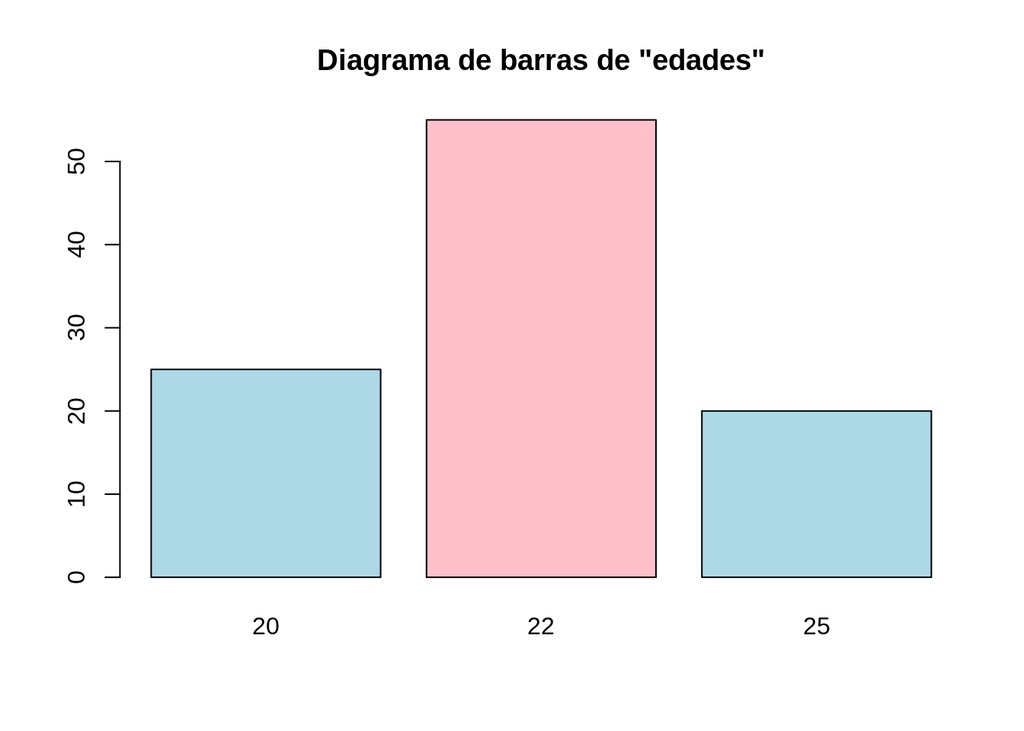

```r
barplot(table(edades), col=c("lightblue", "pink"), main="Diagrama de barras de \"edades\"")
```

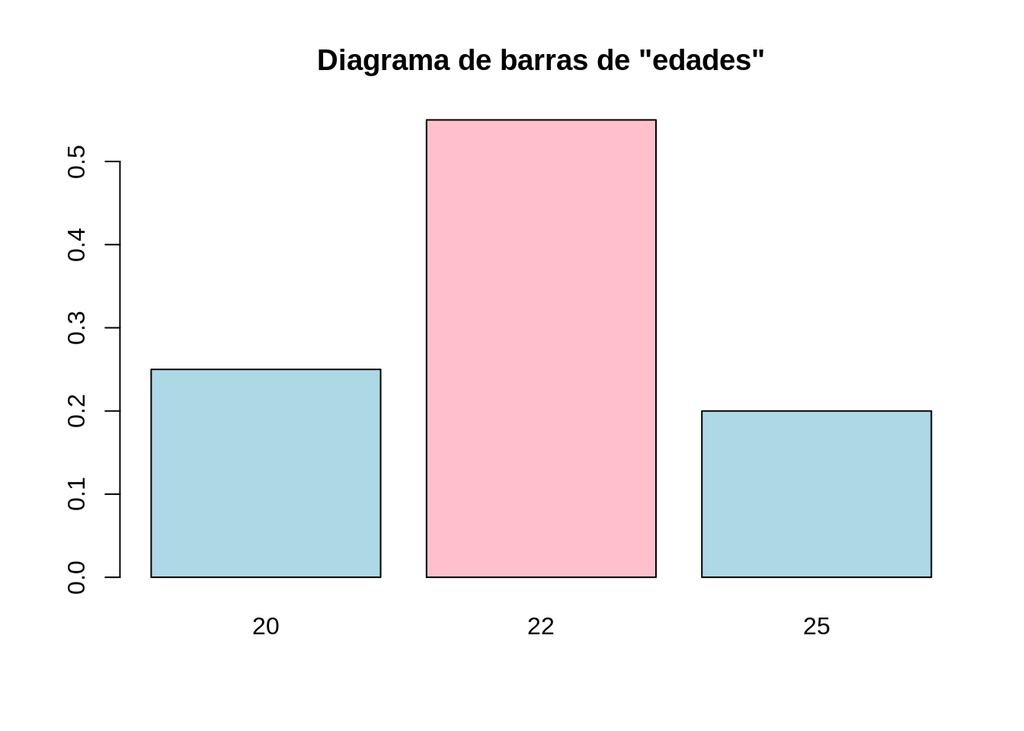

```r
barplot(prop.table(table(edades)), col=c("lightblue", "pink"), main="Diagrama de barras de \"edades\"")
```

#### Con una sola instrucción, dibujad un diagrama circular básico de un vector llamado “alumnos”

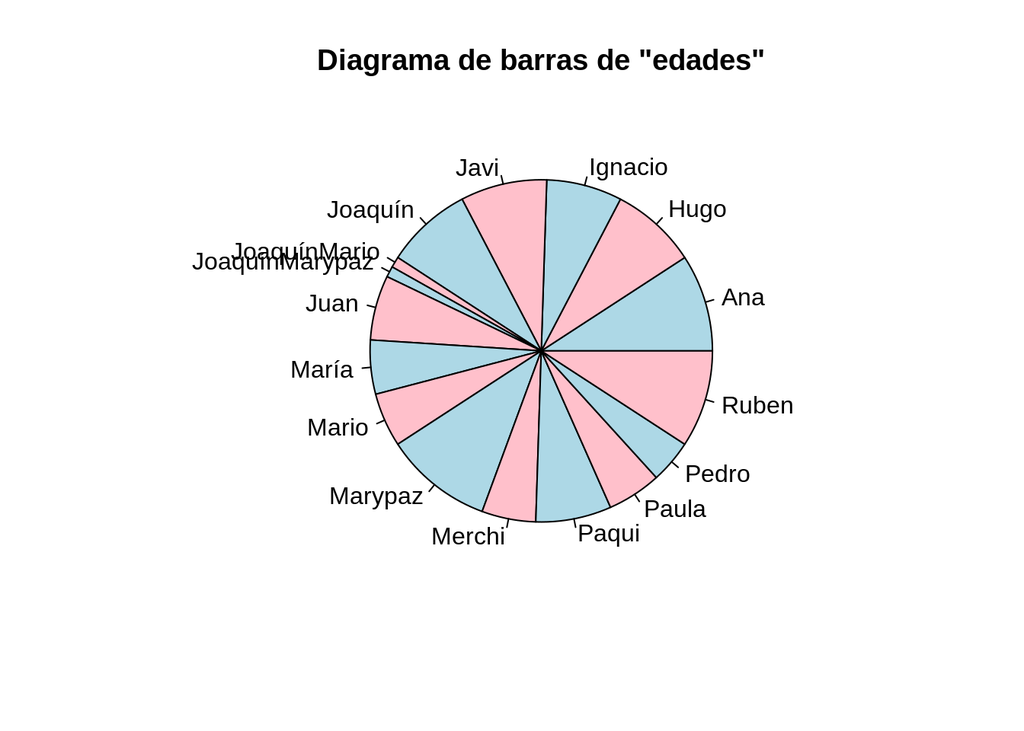

```r
pie(table(alumnos), col=c("lightblue", "pink"), main="Diagrama de barras de \"edades\"")
```

#### La tabla “DNase” es uno de los data frames que tiene predefinidos R. Dad la instrucción que dibuje un diagrama de barras básico de la variable “density” de este mismo data frame

```r
head(DNase)
```

```
##   Run       conc density
## 1   1 0.04882812   0.017
## 2   1 0.04882812   0.018
## 3   1 0.19531250   0.121
## 4   1 0.19531250   0.124
## 5   1 0.39062500   0.206
## 6   1 0.39062500   0.215
```

```r
den = factor(DNase$density)
table(den)
```

```
## den
## 0.011 0.016 0.017 0.018 0.032 0.035 0.043 0.045 0.047  0.05 0.052 0.054
##     1     1     1     1     1     2     1     1     1     1     1     2
## 0.057 0.068  0.07 0.086 0.092 0.094 0.103 0.108 0.118 0.121 0.123 0.124
##     1     1     1     1     1     2     1     1     1     1     1     1
## 0.132 0.135 0.137 0.142 0.148 0.152 0.155 0.159 0.164 0.165 0.166 0.173
##     1     1     1     1     1     1     2     1     1     1     1     1
## 0.182 0.189 0.191   0.2 0.206 0.207 0.215  0.22 0.222 0.224 0.225 0.226
##     2     1     1     1     2     1     1     1     1     1     1     1
## 0.239 0.242 0.246 0.248 0.252 0.256 0.259 0.272 0.273 0.277 0.282  0.36
##     1     1     1     1     1     1     1     1     1     2     1     1
## 0.364 0.374 0.377 0.383 0.385  0.39 0.392 0.395 0.401 0.411  0.42 0.426
##     1     1     1     2     1     1     1     1     1     1     1     2
## 0.427 0.434 0.439  0.44 0.444 0.609 0.614  0.62 0.624  0.64 0.644 0.647
##     1     1     3     1     1     1     1     1     1     1     1     1
## 0.658 0.668 0.672 0.676 0.681 0.684 0.686 0.689  0.69 0.701 0.703 0.704
##     2     1     1     1     1     1     2     1     1     1     1     1
## 0.705 0.973 0.979  0.98 0.994 1.001 1.002 1.019 1.026 1.031 1.035 1.042
##     1     1     1     1     1     1     1     1     1     1     1     1
## 1.043 1.046 1.052  1.06 1.062 1.067 1.072 1.075 1.077 1.078 1.116 1.334
##     1     1     1     1     1     1     1     1     1     1     1     1
##  1.34 1.364 1.381 1.385 1.392 1.398 1.399 1.405 1.406 1.409 1.421 1.424
##     1     1     1     1     1     1     1     1     1     2     1     2
## 1.425 1.459 1.466 1.479 1.526 1.554 1.629 1.693 1.699 1.708  1.71 1.715
##     1     1     1     1     1     1     1     1     1     1     1     1
## 1.721 1.724 1.729  1.73 1.732 1.738 1.739  1.74 1.743  1.75 1.759 1.768
##     1     1     1     1     1     1     1     1     1     1     1     1
## 1.806 1.884 1.914 1.932 2.003
##     1     1     1     1     1
```

```r
prop.table(table(den))
```

```
## den
##       0.011       0.016       0.017       0.018       0.032       0.035
## 0.005681818 0.005681818 0.005681818 0.005681818 0.005681818 0.011363636
##       0.043       0.045       0.047        0.05       0.052       0.054
## 0.005681818 0.005681818 0.005681818 0.005681818 0.005681818 0.011363636
##       0.057       0.068        0.07       0.086       0.092       0.094
## 0.005681818 0.005681818 0.005681818 0.005681818 0.005681818 0.011363636
##       0.103       0.108       0.118       0.121       0.123       0.124
## 0.005681818 0.005681818 0.005681818 0.005681818 0.005681818 0.005681818
##       0.132       0.135       0.137       0.142       0.148       0.152
## 0.005681818 0.005681818 0.005681818 0.005681818 0.005681818 0.005681818
##       0.155       0.159       0.164       0.165       0.166       0.173
## 0.011363636 0.005681818 0.005681818 0.005681818 0.005681818 0.005681818
##       0.182       0.189       0.191         0.2       0.206       0.207
## 0.011363636 0.005681818 0.005681818 0.005681818 0.011363636 0.005681818
##       0.215        0.22       0.222       0.224       0.225       0.226
## 0.005681818 0.005681818 0.005681818 0.005681818 0.005681818 0.005681818
##       0.239       0.242       0.246       0.248       0.252       0.256
## 0.005681818 0.005681818 0.005681818 0.005681818 0.005681818 0.005681818
##       0.259       0.272       0.273       0.277       0.282        0.36
## 0.005681818 0.005681818 0.005681818 0.011363636 0.005681818 0.005681818
##       0.364       0.374       0.377       0.383       0.385        0.39
## 0.005681818 0.005681818 0.005681818 0.011363636 0.005681818 0.005681818
##       0.392       0.395       0.401       0.411        0.42       0.426
## 0.005681818 0.005681818 0.005681818 0.005681818 0.005681818 0.011363636
##       0.427       0.434       0.439        0.44       0.444       0.609
## 0.005681818 0.005681818 0.017045455 0.005681818 0.005681818 0.005681818
##       0.614        0.62       0.624        0.64       0.644       0.647
## 0.005681818 0.005681818 0.005681818 0.005681818 0.005681818 0.005681818
##       0.658       0.668       0.672       0.676       0.681       0.684
## 0.011363636 0.005681818 0.005681818 0.005681818 0.005681818 0.005681818
##       0.686       0.689        0.69       0.701       0.703       0.704
## 0.011363636 0.005681818 0.005681818 0.005681818 0.005681818 0.005681818
##       0.705       0.973       0.979        0.98       0.994       1.001
## 0.005681818 0.005681818 0.005681818 0.005681818 0.005681818 0.005681818
##       1.002       1.019       1.026       1.031       1.035       1.042
## 0.005681818 0.005681818 0.005681818 0.005681818 0.005681818 0.005681818
##       1.043       1.046       1.052        1.06       1.062       1.067
## 0.005681818 0.005681818 0.005681818 0.005681818 0.005681818 0.005681818
##       1.072       1.075       1.077       1.078       1.116       1.334
## 0.005681818 0.005681818 0.005681818 0.005681818 0.005681818 0.005681818
##        1.34       1.364       1.381       1.385       1.392       1.398
## 0.005681818 0.005681818 0.005681818 0.005681818 0.005681818 0.005681818
##       1.399       1.405       1.406       1.409       1.421       1.424
## 0.005681818 0.005681818 0.005681818 0.011363636 0.005681818 0.011363636
##       1.425       1.459       1.466       1.479       1.526       1.554
## 0.005681818 0.005681818 0.005681818 0.005681818 0.005681818 0.005681818
##       1.629       1.693       1.699       1.708        1.71       1.715
## 0.005681818 0.005681818 0.005681818 0.005681818 0.005681818 0.005681818
##       1.721       1.724       1.729        1.73       1.732       1.738
## 0.005681818 0.005681818 0.005681818 0.005681818 0.005681818 0.005681818
##       1.739        1.74       1.743        1.75       1.759       1.768
## 0.005681818 0.005681818 0.005681818 0.005681818 0.005681818 0.005681818
##       1.806       1.884       1.914       1.932       2.003
## 0.005681818 0.005681818 0.005681818 0.005681818 0.005681818
```

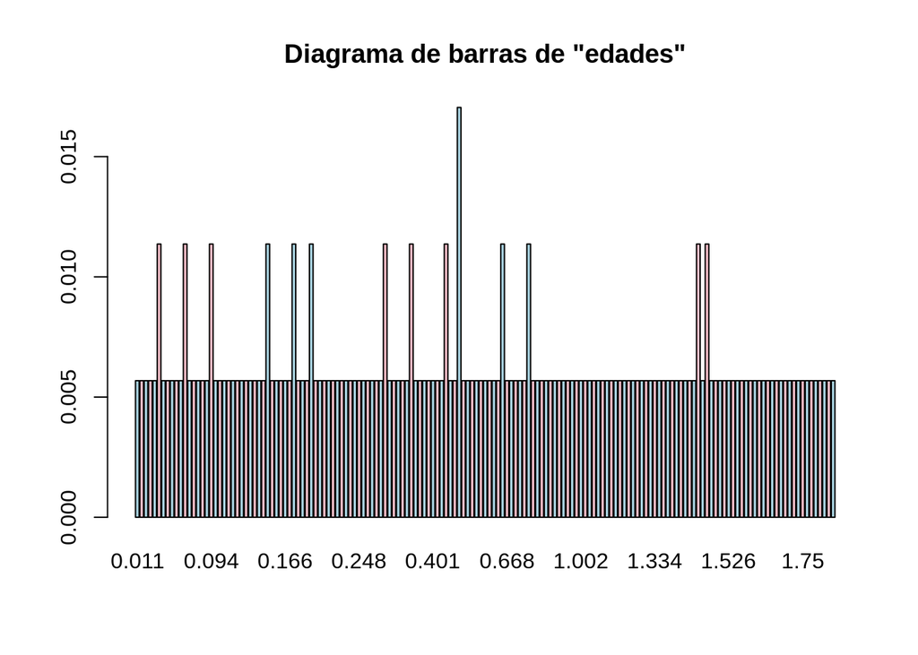

```r
barplot(prop.table(table(den)), col=c("lightblue", "pink"), main="Diagrama de barras de \"edades\"")
```